# Assignment2

wooseokYoon

2023-03-26

제목 : Assignment_2, 작성자 : 20192237 윤우석

문제 상황 : Common Bank는 현재 예금계좌 소유 고객을 대상으로 개인 대출 상품의 가입을 홍보하기 위한 마케팅을 준비중이다. 마케팅 부서에서는 어떤 그룹의 고객들을 타겟팅하여 집중적으로 마케팅 예산을 투입할 지를 고민 중이다. 따라서 k-NN을 활용하여 새로운 고객의 정보가 주어졌을 때 이 고객이 개인 대출 상품을 가입할 지를 예측해 보고자 한다.

```r
# 사용할 패키지 추가
library(dplyr)
library(ggplot2)
library(class)
library(caret)
```

1. 먼저 ID와 ZIP.code는 feature에서 제외한다. 그리고 z-score normalization을 활용하여 feature들의 scale을 일치시킨다. 첫 4,000명의 데이터를 training set으로, 나머지 1,000명의 데이터를 test set으로 사용하고, training set과 test set에서의 target variable의 분포를 비교해 보자.

```r
#데이터 파일 불러오기
CB <- read.csv("CommonBank.csv")
str(CB)
```

```
## 'data.frame':    5000 obs. of  14 variables:
##  $ ID               : int  1 2 3 4 5 6 7 8 9 10 ...
##  $ Age              : int  25 45 39 35 35 37 53 50 35 34 ...
##  $ Experience       : int  1 19 15 9 8 13 27 24 10 9 ...
##  $ Income           : int  49 34 11 100 45 29 72 22 81 180 ...
##  $ ZIP.Code         : int  91107 90089 94720 94112 91330 92121 91711 93943 90089 93023 ...
##  $ Family           : int  4 3 1 1 4 4 2 1 3 1 ...
##  $ CCAvg            : num  1.6 1.5 1 2.7 1 0.4 1.5 0.3 0.6 8.9 ...
##  $ Education        : int  1 1 1 2 2 2 2 3 2 3 ...
##  $ Mortgage         : int  0 0 0 0 0 155 0 0 104 0 ...
##  $ PersonalLoan     : int  0 0 0 0 0 0 0 0 0 1 ...
##  $ SecuritiesAccount: int  1 1 0 0 0 0 0 0 0 0 ...
##  $ CDAccount        : int  0 0 0 0 0 0 0 0 0 0 ...
##  $ Online           : int  0 0 0 0 0 1 1 0 1 0 ...
##  $ CreditCard       : int  0 0 0 0 1 0 0 1 0 0 ...
```

```r
# ID와 ZIP.code는 feature에서 제외.
CB <- CB[,c(-1,-5)]

# target variable인 PersonalLoan을 첫번째 열로 배치
CB <- CB %>% relocate(PersonalLoan)
str(CB)
```

```
## 'data.frame':    5000 obs. of  12 variables:
##  $ PersonalLoan     : int  0 0 0 0 0 0 0 0 0 1 ...
##  $ Age              : int  25 45 39 35 35 37 53 50 35 34 ...
##  $ Experience       : int  1 19 15 9 8 13 27 24 10 9 ...
##  $ Income           : int  49 34 11 100 45 29 72 22 81 180 ...
##  $ Family           : int  4 3 1 1 4 4 2 1 3 1 ...
##  $ CCAvg            : num  1.6 1.5 1 2.7 1 0.4 1.5 0.3 0.6 8.9 ...
##  $ Education        : int  1 1 1 2 2 2 2 3 2 3 ...
##  $ Mortgage         : int  0 0 0 0 0 155 0 0 104 0 ...
##  $ SecuritiesAccount: int  1 1 0 0 0 0 0 0 0 0 ...
##  $ CDAccount        : int  0 0 0 0 0 0 0 0 0 0 ...
##  $ Online           : int  0 0 0 0 0 1 1 0 1 0 ...
##  $ CreditCard       : int  0 0 0 0 1 0 0 1 0 0 ...
```

```r
# target variable을 factor 형식으로 변환 및 라벨링
CB$PersonalLoan <- factor(CB$PersonalLoan, levels = c(1,0), labels = c("Accept", "Reject"))

# z-score normalization 함수 정의
z_normalize <- function(x) {
 return ((x - mean(x)) / sd(x))
}

# 독립변수 scaling
CB_n <- as.data.frame(lapply(CB[2:12], z_normalize))
str(CB_n)
```

```
## 'data.frame':    5000 obs. of  11 variables:
##  $ Age              : num  -1.7742 -0.0295 -0.5529 -0.9019 -0.9019 ...
##  $ Experience       : num  -1.6659 -0.0963 -0.4451 -0.9683 -1.0555 ...
##  $ Income           : num  -0.538 -0.864 -1.364 0.57 -0.625 ...
##  $ Family           : num  1.397 0.526 -1.217 -1.217 1.397 ...
##  $ CCAvg            : num  -0.193 -0.251 -0.537 0.436 -0.537 ...
##  $ Education        : num  -1.049 -1.049 -1.049 0.142 0.142 ...
##  $ Mortgage         : num  -0.555 -0.555 -0.555 -0.555 -0.555 ...
##  $ SecuritiesAccount: num  2.929 2.929 -0.341 -0.341 -0.341 ...
##  $ CDAccount        : num  -0.254 -0.254 -0.254 -0.254 -0.254 ...
##  $ Online           : num  -1.22 -1.22 -1.22 -1.22 -1.22 ...
##  $ CreditCard       : num  -0.645 -0.645 -0.645 -0.645 1.549 ...
```

```r
# train set과 test set의 데이터 할당.
CB_train <- CB_n[1:4000, ]
CB_test <- CB_n[4001:5000, ]

# train set과 test set의 종속변수 값 할당.
CB_train_labels <- CB[1:4000, 1]
CB_test_labels <- CB[4001:5000, 1]


# train set의 target variable 분포
table(CB_train_labels)
```

```
## CB_train_labels
## Accept Reject
##    397   3603
```

```r
# test set의 target variable 분포
table(CB_test_labels)
```

```
## CB_test_labels
## Accept Reject
##     83    917
```

```r
# table을 datafrmae 형식으로 변환
df1 <- data.frame(table(CB_train_labels))
df2 <- data.frame(table(CB_test_labels))

# 열이름을 맞춘 후 행방향으로 합침
colnames(df1)[1] <- "PersonalLoan"
colnames(df2)[1] <- "PersonalLoan"
df_tv <- rbind(df1, df2)

# train set과 test set을 나누는 factor 요소 추가
train_test <- factor(c("train", "train", "test", "test"))
df_tv$train_test <- train_test
str(df_tv)
```

```
## 'data.frame':    4 obs. of  3 variables:
##  $ PersonalLoan: Factor w/ 2 levels "Accept","Reject": 1 2 1 2
##  $ Freq        : int  397 3603 83 917
##  $ train_test  : Factor w/ 2 levels "test","train": 2 2 1 1
```

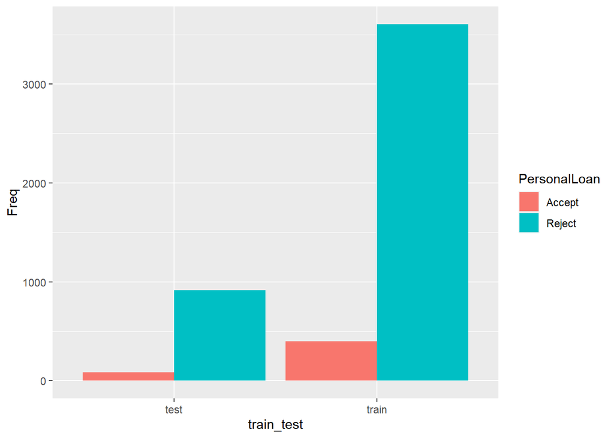

```r
# 막대 그래프로 시각화
p1 <- ggplot(df_tv, aes(x= train_test, y=Freq, fill = PersonalLoan)) + geom_bar(stat = "identity", position = "dodge")
p1
```

2. 7-NN을 적용하고, 결과를 분석해보자.

```r
# k를 7로 knn 진행
CB_test_pred <- knn(train = CB_train, test = CB_test, cl = CB_train_labels, k=7)

# 결과 분석
confusionMatrix(CB_test_pred, CB_test_labels)
```

```
## Confusion Matrix and Statistics
##
##           Reference
## Prediction Accept Reject
##     Accept     49      4
##     Reject     34    913
##
##                Accuracy : 0.962
##                  95% CI : (0.9482, 0.973)
##     No Information Rate : 0.917
##     P-Value [Acc > NIR] : 8.683e-09
##
##                   Kappa : 0.7013
##
##  Mcnemar's Test P-Value : 2.546e-06
##
##             Sensitivity : 0.5904
##             Specificity : 0.9956
##          Pos Pred Value : 0.9245
##          Neg Pred Value : 0.9641
##              Prevalence : 0.0830
##          Detection Rate : 0.0490
##    Detection Prevalence : 0.0530
##       Balanced Accuracy : 0.7930
##
##        'Positive' Class : Accept
##
```

3. Training set 중에서 마지막 800명의 데이터를 validation set으로 사용하여, 다양한 k 값에 대해 k-NN을 적용해 보고 예측 성능을 비교해 보자. k가 어떤 값을 가질때 모델의 성능이 가장 우수한가?

```r
# train set과 validation set의 데이터 할당.
CB_train <- CB_n[1:3200, ]
CB_valid <- CB_n[3201:4000, ]

# train set과 validation set의 종속변수 값 할당.
CB_train_labels <- CB[1:3200, 1]
CB_valid_labels <- CB[3201:4000, 1]

# vector 변수 지정
K = vector()
Accuracy = vector()

# k에 따른 모델의 Accuracy를 측정한 후 그 결과 값을 dataframe에 추가
for(i in seq(1, 31, by=2)){
  CB_test_pred <- knn(train = CB_train, test = CB_valid, cl = CB_train_labels, k=i)
  model_pred <- confusionMatrix(CB_test_pred, CB_valid_labels)
  K <- append(K, i)
  Accuracy <- append(Accuracy, model_pred$overall[1])
  df_Accuracy <- data.frame(K, Accuracy)
}
df_Accuracy
```

```
##     K Accuracy
## 1   1  0.95750
## 2   3  0.94750
## 3   5  0.95250
## 4   7  0.94500
## 5   9  0.94625
## 6  11  0.93875
## 7  13  0.93625
## 8  15  0.93500
## 9  17  0.93375
## 10 19  0.93625
## 11 21  0.93625
## 12 23  0.93375
## 13 25  0.93250
## 14 27  0.93125
## 15 29  0.93000
## 16 31  0.93000
```

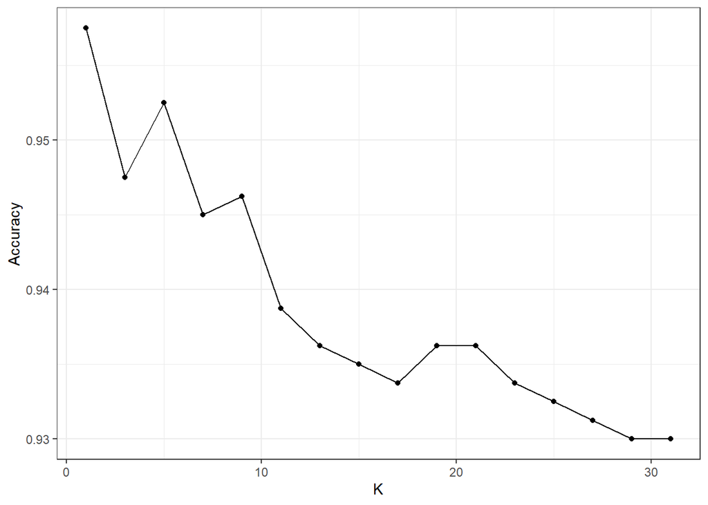

```r
# k에 따른 모델의 Accuracy 변화 그래프로 시각화
p3 <- ggplot(df_Accuracy, aes(x=K, y=Accuracy)) + geom_line() + geom_point() + theme_bw()
p3
```

K가 1일 때, 모델의 성능이 가장 좋다는 것을 알 수 있다.

4. Training set에 대해 5-fold cross validation을 5회 반복하여 best k 값을 찾아보자. Best k 값으로 만들어지는 최종 model에 test set을 적용하여 model의 성능을 report하자.

```r
# z-normalized를 하기 전 데이터로 train set과 test set 분할
CB_train <- CB[1:4000, ]
CB_test <- CB[4001:5000, ]

# scaling 방식 변수 할당
z_normalized <- c("center", "scale")

# 5-fold cross validation 5회 반복 변수 할당
cv <- trainControl(method="repeatedcv", number = 5, repeats = 5)

# k의 값 변화를 변수 지정
tune_grid <- expand.grid(k = seq(1, 31, 2))

# 모델 train 이후 validation set을 이용한 k 값에 따른 모델 성능 검증 및 파악
knn_fit <- train(data=CB_train, PersonalLoan~., method="knn", trControl = cv, preProcess = z_normalized, tuneGrid = tune_grid)
knn_fit
```

```
## k-Nearest Neighbors
##
## 4000 samples
##   11 predictor
##    2 classes: 'Accept', 'Reject'
##
## Pre-processing: centered (11), scaled (11)
## Resampling: Cross-Validated (5 fold, repeated 5 times)
## Summary of sample sizes: 3200, 3200, 3200, 3200, 3200, 3201, ...
## Resampling results across tuning parameters:
##
##   k   Accuracy   Kappa
##    1  0.9549998  0.7252433
##    3  0.9583499  0.7289187
##    5  0.9548496  0.6969533
##    7  0.9538501  0.6840564
##    9  0.9511999  0.6601998
##   11  0.9493997  0.6432050
##   13  0.9466503  0.6217474
##   15  0.9448003  0.6046044
##   17  0.9431003  0.5891303
##   19  0.9426501  0.5846931
##   21  0.9421507  0.5794008
##   23  0.9407510  0.5663818
##   25  0.9402009  0.5603624
##   27  0.9393009  0.5508821
##   29  0.9381511  0.5383399
##   31  0.9373005  0.5292703
##
## Accuracy was used to select the optimal model using the largest value.
## The final value used for the model was k = 3.
```

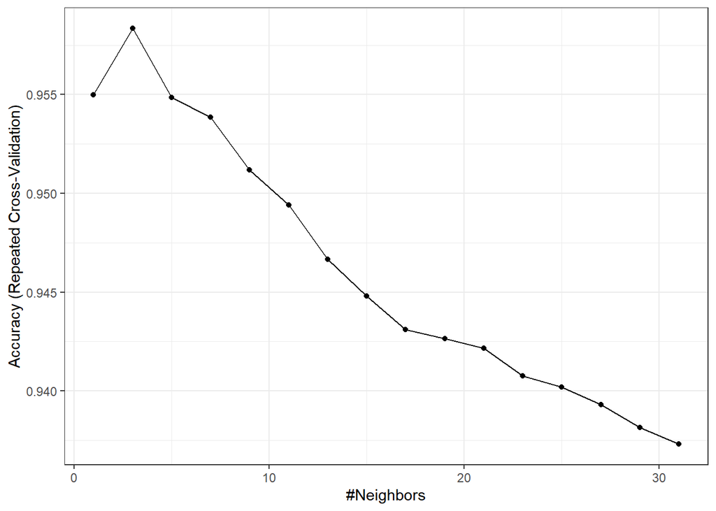

```r
# k에 따른 Accuracy 변화 그래프로 시각화
ggplot(knn_fit) + theme_bw()
```

```r
# best k값으로 만들어진 최종 모델로 test set 적용시, 모델의 성능
test_pred <- predict(knn_fit, CB_test[,-1])
confusionMatrix(test_pred, CB_test_labels, positive = "Accept")
```

```
## Confusion Matrix and Statistics
##
##           Reference
## Prediction Accept Reject
##     Accept     54      4
##     Reject     29    913
##
##                Accuracy : 0.967
##                  95% CI : (0.954, 0.9772)
##     No Information Rate : 0.917
##     P-Value [Acc > NIR] : 9.350e-11
##
##                   Kappa : 0.7488
##
##  Mcnemar's Test P-Value : 2.943e-05
##
##             Sensitivity : 0.6506
##             Specificity : 0.9956
##          Pos Pred Value : 0.9310
##          Neg Pred Value : 0.9692
##              Prevalence : 0.0830
##          Detection Rate : 0.0540
##    Detection Prevalence : 0.0580
##       Balanced Accuracy : 0.8231
##
##        'Positive' Class : Accept
##
```

k가 3일 때, 가장 성능이 좋은 모델이 되고 그 때에 test set에 대한 모델의 성능은 Accuracy : 0.967이다.

5. 3번과 4번에서 활용한 training 방식의 장단점을 비교해보자.

3번의 장점은 4번에 비해 훈련 속도가 빠르다는 장점이 있다. 단점으로는 특정 validation set을 이용하기 때문에 과적합이 된다. 즉, 모델이 매우 변화되기 쉽고, 비현실적이다.  
4번은 여러 train set에서 k-fold cross-validaiton을 이용하면서 train set과 validation set을 변화해가면서 자료 추출의 균일성을 확보했다고 볼 수 있다. 즉, 4번 모델은 상대적으로 일반화된 성능을 가질 수 있으며 그로 인해 안정적이다. 단점으로는 3번에 비해 훈련 속도가 느리다는 단점이 있다.